# P-Values 1

Nate Breznau

9/24/2021

### P-Value 1. Comparing Means

In experimental research - more often psychology and economics, the p-value is often the statistic used to determine if the average outcome in the **treatment** group is different from the **control** group. But this can also be used to determine differences in means between any groups - whether they were part of an experiement or just social groups that exist in a given population. In this case the p-value gives the same information as a t-test.

Let us compare happiness for individuals that are highest in income in thei society with those who are lowest in income to test the hypothesis that *money can buy happiness*.

##### Load data

These World Values Survey data were imported using the script WVS_import.R found in the “prep” folder of this project. Fourteen variables were selected to keep things simple.

```r
wvs_pvalue <- read_rds(here::here("data","wvs_pvalue.rds"))
```

#### Happiness and Income T-Test (P-Value)

Start with a t-test. This will compare the means in two income groups. Let’s look only at Germany If we use the enitre WVS data there are over 70 thousand cases and this will inevitably lead to tiny standard errors. (Switzerland is not in the Wave 7 data unfortunately)

```r
wvs_pvalue <- as.data.frame(wvs_pvalue) %>%
  mutate(income_lohi = ifelse(income == 1, "Low", ifelse(income == 3, "High", NA)), # only low and high incomes
         happy = ifelse(happiness > 0, happiness, NA), # remove missing
         happy = car::recode(happy, "1=4;2=3;3=2;4=1")) # make happiest people with higher scores

# select only Germany (= DEU in iso3c language)
wvs_pvalueDEU <- wvs_pvalue %>%
  subset(iso3c == "DEU")

# t-test
t.test(wvs_pvalueDEU$happy[wvs_pvalueDEU$income == 1], y = wvs_pvalueDEU$happy[wvs_pvalueDEU$income == 3])
```

```
##
##  Welch Two Sample t-test
##
## data:  wvs_pvalueDEU$happy[wvs_pvalueDEU$income == 1] and wvs_pvalueDEU$happy[wvs_pvalueDEU$income == 3]
## t = -7.5118, df = 205.55, p-value = 1.754e-12
## alternative hypothesis: true difference in means is not equal to 0
## 95 percent confidence interval:
##  -0.6788552 -0.3965899
## sample estimates:
## mean of x mean of y
##  2.827869  3.365591
```

#### Visualize Mean Comparison

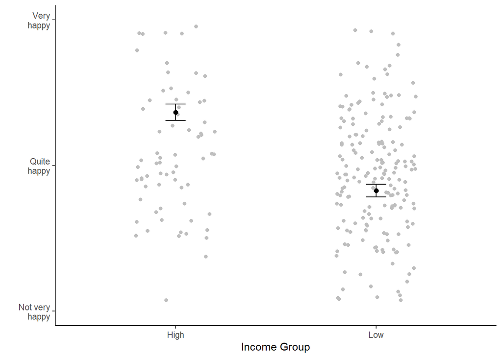

```r
# reproducible jitter
set.seed(90210)
jitter <- position_jitter(width = 0.2, height = 0.5)

# Germany specific
wvs_pvalueDEU_sum <- wvs_pvalueDEU %>%
  group_by(income_lohi) %>%
  summarise(happy_m = mean(happy, na.rm = T),
            happy_sd = sd(happy, na.rm = T),
            happy_n = n(),
            happy = happy_m) %>%
  mutate(happy_se = happy_sd / sqrt(happy_n)) %>%
  subset(!is.na(income_lohi))

  ggplot() +
     geom_point(data = subset(wvs_pvalueDEU, !is.na(income_lohi)),  aes(x = income_lohi, y = happy), color = "grey", position = jitter) +
     geom_point(data = wvs_pvalueDEU_sum, aes(x = income_lohi, y = happy), size = 2) +
     geom_errorbar(data = wvs_pvalueDEU_sum, aes(ymin = happy - happy_se, ymax = happy + happy_se, x = income_lohi), width = .1) +

     scale_y_continuous(breaks = c(1,2,3,4),
                        labels = c("1" = "Not at all\nhappy",
                                                     "2" = "Not very\nhappy",
                                                     "3" = "Quite\nhappy",
                                                     "4" = "Very\nhappy"),
                        limits = c(2,4)) +
     labs(x = "Income Group", y = " ") +
     theme_classic()
```

#### Visualize all countries in WVS

```r
# summarize by country
wvs_pvalue_sum <- wvs_pvalue %>%
  group_by(iso3c, income_lohi) %>%
  summarise(happy_m = mean(happy, na.rm = T),
            happy_sd = sd(happy, na.rm = T),
            happy_n = n(),
            happy = happy_m) %>%
  mutate(happy_se = happy_sd / sqrt(happy_n)) %>%
  subset(!is.na(income_lohi))
```

Loop the visualization by country

```r
for (c in unique(wvs_pvalue_sum$iso3c)) {
  wvs_pvalue_sum_temp <- wvs_pvalue_sum %>%
    subset(iso3c == c)
  wvs_temp <- wvs_pvalue %>%
    subset(iso3c == c & !is.na(income_lohi))

  # custom titles for each plot
  gtitle <- countrycode(c, "iso3c", "country.name", custom_match = c("AND" = "Andorra"))



  plot_temp <- ggplot() +
           geom_point(data = subset(wvs_temp, !is.na(income_lohi)),  aes(x = income_lohi, y = happy), color = "grey", position = jitter) +
           geom_point(data = wvs_pvalue_sum_temp, aes(x = income_lohi, y = happy), size = 2.5) +
           geom_errorbar(data = wvs_pvalue_sum_temp, aes(ymin = happy - happy_se, ymax = happy + happy_se, x = income_lohi), width = .15) +
           scale_y_continuous(breaks = c(1,2,3,4),
                        labels = c("1" = "Not at all\nhappy",
                                                     "2" = "Not very\nhappy",
                                                     "3" = "Quite\nhappy",
                                                     "4" = "Very\nhappy"),
                        limits = c(2,4)) +
           annotate("text", x = 1.5, y = mean(wvs_pvalue_sum_temp$happy), label = paste0("p = ", sprintf('%.3f', t.test(wvs_temp$happy[wvs_temp$income == 1], y=wvs_temp$happy[wvs_temp$income == 3])$p.value))) + # t-test here to extract p-value
           labs(x = "Income Group", y = " ", title = paste0(gtitle, " (", c, ")")) +
           theme_classic()

agg_png(here::here("results", "means_p", paste0(c,"_tplot.png")), height = 700, width = 500, res = 144)
print(plot_temp)
dev.off()
}
```

A figure for each country can be found in the folder results. Here we plot Germany and Ethiopia, respective examples of a significant difference (p<0.05) and a not significant difference (p>=0.05).

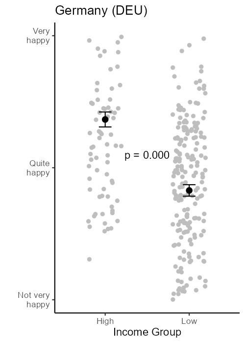

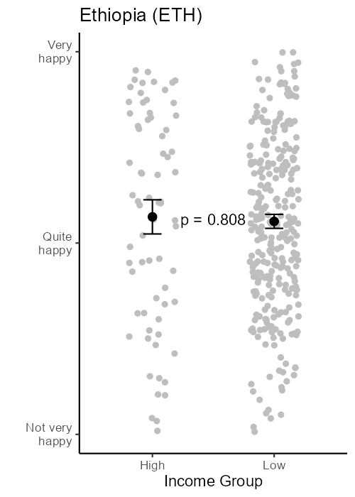

```r
knitr::include_graphics(c(here::here("results", "means_p", "DEU_tplot.png"), here::here("results", "means_p", "ETH_tplot.png")))
```